## Study on Prediction of Human Activity

### Executive Summary

This project is based on a study of human activity (see References). The measurements originate from accelerometers worn by differents participants while doing an exercise in 5 different (more or less correct) ways, classified from A to E.  
This project builds a machine learning algorithm in order predict in which way the exercise was done. After some data cleaning, 52 potential regressor variables remained next to the outcome, i.e. classe A to E. The model itself was built using random forest after splitting the original training data again by ratio 70/30 into a training and testing set.  
Validation (with the 70% training data) and prediction (on the 30% testing data) promised highly accurate results, so that finally the prediction was run on the original testing data of 20 participants to obtain a character from A to E as a result for the final submission.

### Data Source

The data is provided online from the Human Activity Recognition Website. Two files are downloaded and directly read into dataframes with the respective names.  
- pml-training is used to build the model, i.e. it is split into train and test set.  
- pml-testing contains the 20 test cases for validation on coursera.

```r
if (!file.exists("./pml-training.csv")) {
  download.file("https://d396qusza40orc.cloudfront.net/predmachlearn/pml-training.csv", destfile="./pml-training.csv")
  }
if (!file.exists("./pml-testing.csv")) {
  download.file("https://d396qusza40orc.cloudfront.net/predmachlearn/pml-testing.csv", destfile="./pml-testing.csv")
  }
training.raw <- read.csv("pml-training.csv")
testing.raw <- read.csv("pml-testing.csv")
```

### Data Cleaning

An exploratory analysis is carried out on the pml-testing data as it is not useful to include regressors which would not be present with the 20 test cases. Therefore, a vector with the variables (i.e. column numbers) to delete is created. As the experiments are considered to be independent from each other, the first 7 variables containing information of the experiment procedure (id, name, timestamp) are manually excluded. Furthermore, the summary is checked for variables containing only NA’s. Finally, those columns are deleted by subsetting.

```r
summ.test <- summary(testing.raw)
todelete <- rbind(1,2,3,4,5,6,7) #the first 7 columns contain only information on the experiment procedure
for (i in 8:160) {
  if(summ.test[2,i]=="NA's:20       ") { #this is the exact string in case of columns containing only NA's
    todelete <- rbind(todelete,i) #the vector 'todelete' is filled up with the column numbers to delete and later used for subsetting
  }
}
training.tidy <- training.raw[,-todelete]
testing.tidy <- testing.raw[,-todelete]
```

Both dataframes (training and testing) are treated equally. At the end, there are 52 potential regressors plus the outcome (classe variable) in the training data or the problem_id in the testing data.

### Prediction Model

The dataframe ‘training.tidy’ is used to built the model. Therefore it is split into a ‘training’ set and a ‘testing’ set in the ratio 70/30.  
Attention, ‘testing’ is a fraction of ‘training.tidy’, and has nothing to to with ‘testing.tidy’, i.e. the cleaned set of 20 samples to be used for the final submission.  
The prediction model is built using the randomForest package with classe as the outcome and all “cleaned” 52 variables as regressors.

```r
library(caret)
library(randomForest)
set.seed(4711)
inTrain <- createDataPartition(training.tidy$classe, p=0.7, list=FALSE)
training <- training.tidy[inTrain,]
testing <- training.tidy[-inTrain,]
modFitRF <- randomForest(classe ~ ., data=training)
```

### Model Validation

The final model of the Random Forest packages gives accuracy measures.

```r
modFitRF
```

```
##
## Call:
##  randomForest(formula = classe ~ ., data = training)
##                Type of random forest: classification
##                      Number of trees: 500
## No. of variables tried at each split: 7
##
##         OOB estimate of  error rate: 0.52%
## Confusion matrix:
##      A    B    C    D    E class.error
## A 3902    3    0    1    0    0.001024
## B   16 2637    5    0    0    0.007901
## C    0   11 2384    1    0    0.005008
## D    0    0   27 2223    2    0.012877
## E    0    0    2    4 2519    0.002376
```

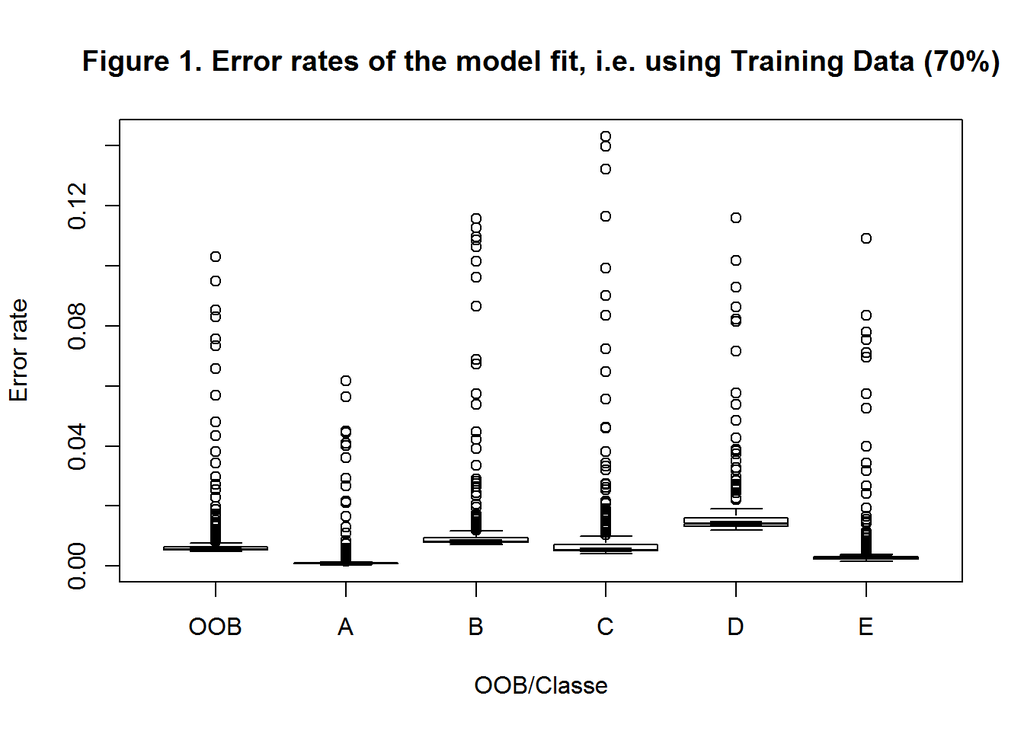

```r
boxplot.matrix(modFitRF$err.rate,use.cols=TRUE,notch=TRUE,xlab="OOB/Classe",ylab="Error rate",main = "Figure 1. Error rates of the model fit, i.e. using Training Data (70%)")
```

### Prediction

Then a prediction is carried out on the 30% of the data which was not used for the model fit.

```r
predRF <- predict(modFitRF, testing)
conMat <- confusionMatrix(predRF,testing$classe)
conMat
```

```
## Confusion Matrix and Statistics
##
##           Reference
## Prediction    A    B    C    D    E
##          A 1673    2    0    0    0
##          B    0 1136    8    0    0
##          C    0    1 1016   10    2
##          D    0    0    2  953    1
##          E    1    0    0    1 1079
##
## Overall Statistics
##
##                Accuracy : 0.995
##                  95% CI : (0.993, 0.997)
##     No Information Rate : 0.284
##     P-Value [Acc > NIR] : <2e-16
##
##                   Kappa : 0.994
##  Mcnemar's Test P-Value : NA
##
## Statistics by Class:
##
##                      Class: A Class: B Class: C Class: D Class: E
## Sensitivity             0.999    0.997    0.990    0.989    0.997
## Specificity             1.000    0.998    0.997    0.999    1.000
## Pos Pred Value          0.999    0.993    0.987    0.997    0.998
## Neg Pred Value          1.000    0.999    0.998    0.998    0.999
## Prevalence              0.284    0.194    0.174    0.164    0.184
## Detection Rate          0.284    0.193    0.173    0.162    0.183
## Detection Prevalence    0.285    0.194    0.175    0.162    0.184
## Balanced Accuracy       0.999    0.998    0.994    0.994    0.998
```

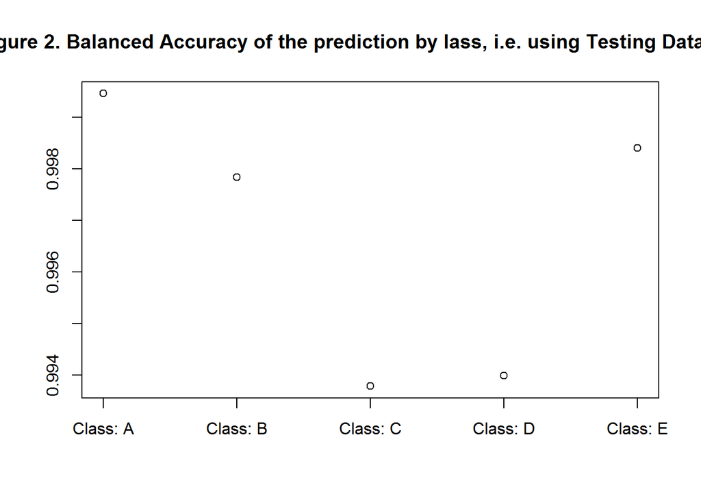

```r
plot(conMat$byClass[,8], xaxt = "n", xlab = "", ylab = "", main = "Figure 2. Balanced Accuracy of the prediction by lass, i.e. using Testing Data (30%)")
axis(side = 1, at = 1:5, labels = names(conMat$byClass[,8]))
```

The confusion matrix shows an accuracy of 99.5242%. Figure 2 shows the balanced accuracy of the prediction by class.

### Prediction Assignment Submission

Finally, the model is used to predict the 20 samples in the initially given test set (called testing.tidy in this study). The result is stored in a character vector predRF20.  
The following steps correspond to the instructions to build the files for submission.

```r
predRF20 <- predict(modFitRF, testing.tidy)
answers <- as.character(predRF20) # in order to avoid strange results with the following submission code
pml_write_files = function(x){
  n = length(x)
  for(i in 1:n){
    filename = paste0("problem_id_",i,".txt")
    write.table(x[i],file=filename,quote=FALSE,row.names=FALSE,col.names=FALSE)
  }
}
pml_write_files(answers)
```

### References

The data for this project come from this source:  
http://groupware.les.inf.puc-rio.br/har